# 27 - Time Series Regression

Regression with a Trend and Seasonality

Fadel M Megahed

May 02, 2022

# 1 Recap of What we Learned Last Week

1. Conduct tests for significance of individual regression coefficients.
2. Use a simple linear regression model for trend adjustment.
3. Interpret regression diagnostic plots.
4. Create prediction intervals for individual values of the response variable.
5. Discuss Exam 03 (Not in R).

## 1.1 Required Packages

In the code chunk below, we use the `pacman` package to load the required packages and install them if necessary.

```r
if(require(pacman)==FALSE) install.packages("pacman")
```

```r
pacman::p_load(tidyverse,
               magrittr, # for the two-way pipe
               fpp2, # accuracy() function, Arima(), auto.arima(),
               astsa, # package is for the required data
               plotly, # for interactive graphs
               stargazer)

source('resPlotTS.R') # loading our resPlot function from Last Class

options(scipen = 999)
```

## 1.2 A Refresher of Time-Series Regression Concepts Learned so Far

Using the `jj` dataset from the [astsa package](https://cran.r-project.org/web/packages/astsa/astsa.pdf), we have discussed how we can regress the logged EPS for J&J as a function of time. The regression can be performed using the: (a) `lm()` from base R, where we would need to create the time-feature(s) ourselves, or (b) using the `tslm()` from the forecast package (which we typically load using fpp2). **In class, I will quickly go through the process of fitting the data to ensure that we are all on the same page.**

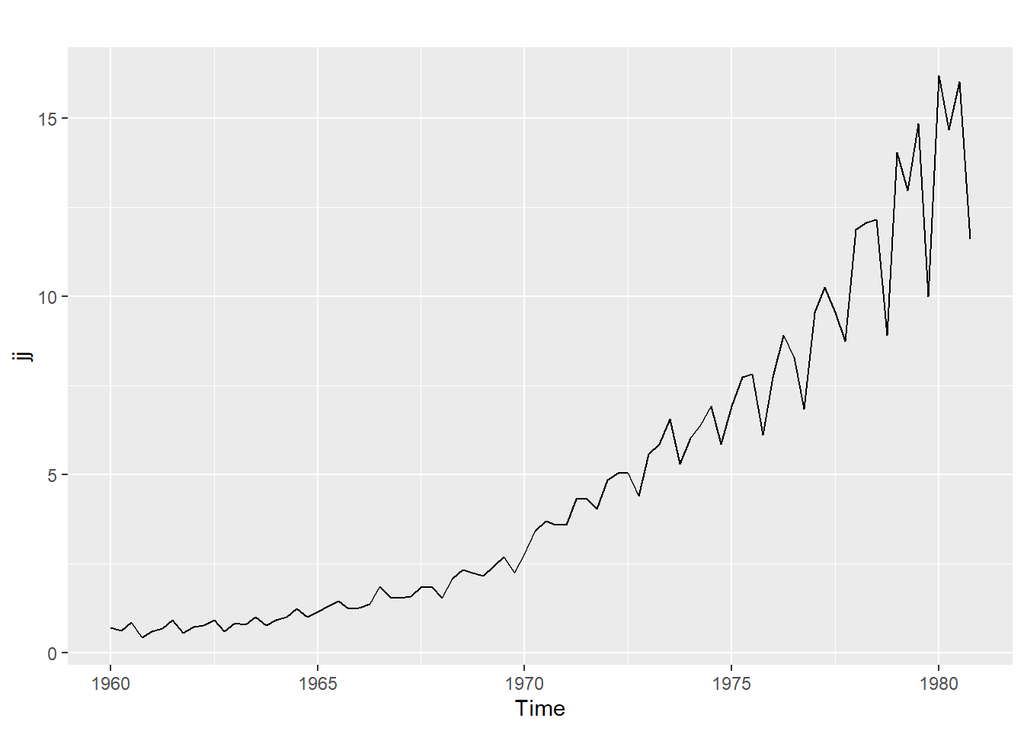

```r
jj = jj
autoplot(jj)
```

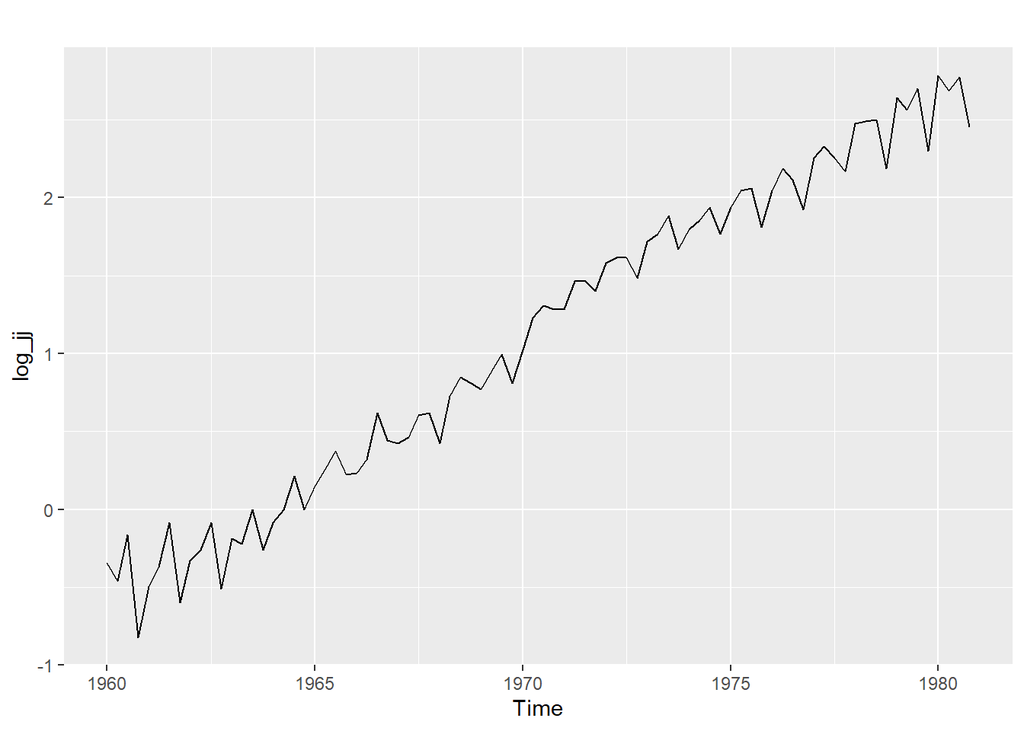

```r
log_jj = log(jj)
autoplot(log_jj)
```

```r
t = time(log_jj)

model1 = lm(log_jj ~ t)
summary(model1)
```

```
##
## Call:
## lm(formula = log_jj ~ t)
##
## Residuals:
##      Min       1Q   Median       3Q      Max
## -0.38309 -0.08569  0.00297  0.09984  0.38016
##
## Coefficients:
##                Estimate  Std. Error t value            Pr(>|t|)
## (Intercept) -327.547628    5.622759  -58.25 <0.0000000000000002 ***
## t              0.166797    0.002854   58.45 <0.0000000000000002 ***
## ---
## Signif. codes:  0 '***' 0.001 '**' 0.01 '*' 0.05 '.' 0.1 ' ' 1
##
## Residual standard error: 0.1585 on 82 degrees of freedom
## Multiple R-squared:  0.9766, Adjusted R-squared:  0.9763
## F-statistic:  3416 on 1 and 82 DF,  p-value: < 0.00000000000000022
```

$y_t = -327.547628 + 0.166797t$

```r
stargazer(model1, type = 'html')
```

|  | *Dependent variable:* |
| --- | --- |
|  | log_jj |
| t | 0.167*** |
|  | (0.003) |
| Constant | -327.548*** |
|  | (5.623) |
| Observations | 84 |
| R<sup>2</sup> | 0.977 |
| Adjusted R<sup>2</sup> | 0.976 |
| Residual Std. Error | 0.159 (df = 82) |
| F Statistic | 3,416.473*** (df = 1; 82) |
| *Note:* | p<0.1; p<0.05; p<0.01 |

### 1.2.1 Model2 from tslm

```r
model2 = tslm(log_jj ~ trend)
summary(model2)
```

```
##
## Call:
## tslm(formula = log_jj ~ trend)
##
## Residuals:
##      Min       1Q   Median       3Q      Max
## -0.38309 -0.08569  0.00297  0.09984  0.38016
##
## Coefficients:
##               Estimate Std. Error t value            Pr(>|t|)
## (Intercept) -0.6677756  0.0349073  -19.13 <0.0000000000000002 ***
## trend        0.0416992  0.0007134   58.45 <0.0000000000000002 ***
## ---
## Signif. codes:  0 '***' 0.001 '**' 0.01 '*' 0.05 '.' 0.1 ' ' 1
##
## Residual standard error: 0.1585 on 82 degrees of freedom
## Multiple R-squared:  0.9766, Adjusted R-squared:  0.9763
## F-statistic:  3416 on 1 and 82 DF,  p-value: < 0.00000000000000022
```

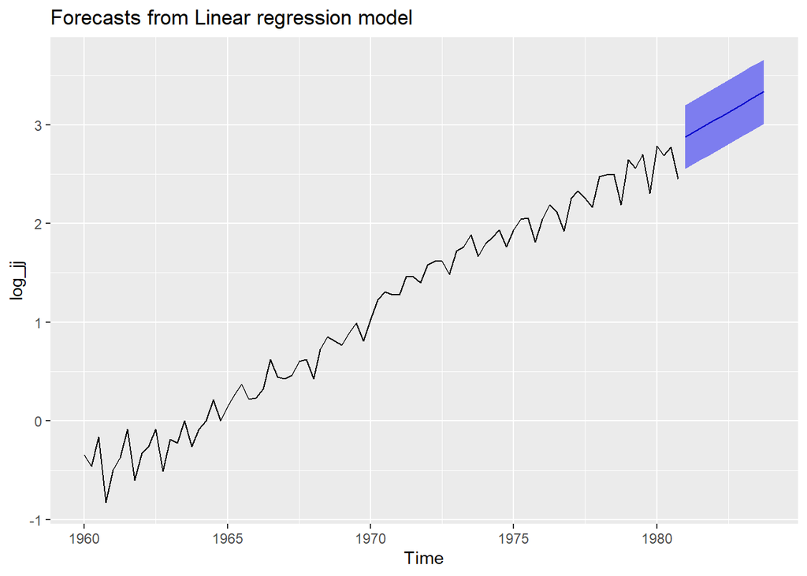

```r
point_fcts = forecast(model2, h = 12, level = 95)$mean

eps_fcts = exp(point_fcts)

forecast(model2, h = 12, level = 95) %>% autoplot()
```

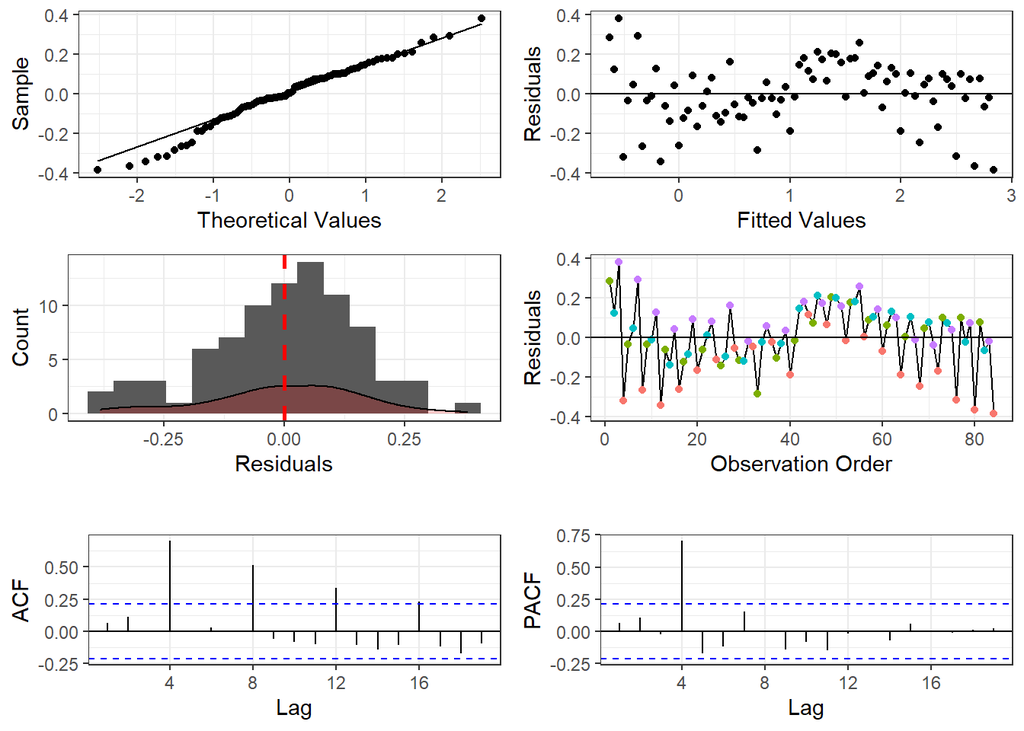

```r
resplot(res = model2$residuals,
        fit = model2$fitted.values,
        freq = 4)
```

## 1.3 Main Learning Outcomes for Today’s Class

1. Use regression to account for seasonality in a time series.
2. Compare the performance of the regression model with that obtained from `auto.arima()`.

# 2 Seasonal Regression

## 2.1 Using the `lm()` Function

```r
# to ensure that R treats the cycle as a categorical variable
# we use the factor function to convert the 1, 2, 3, 4 to factors
q = cycle(log_jj) %>% factor()

model3 = lm(log_jj ~ t + q)
model.matrix(model3)
```

```
##    (Intercept)       t q2 q3 q4
## 1            1 1960.00  0  0  0
## 2            1 1960.25  1  0  0
## 3            1 1960.50  0  1  0
## 4            1 1960.75  0  0  1
## 5            1 1961.00  0  0  0
## 6            1 1961.25  1  0  0
## 7            1 1961.50  0  1  0
## 8            1 1961.75  0  0  1
## 9            1 1962.00  0  0  0
## 10           1 1962.25  1  0  0
## 11           1 1962.50  0  1  0
## 12           1 1962.75  0  0  1
## 13           1 1963.00  0  0  0
## 14           1 1963.25  1  0  0
```

[output cut: 75 more lines]

```r
summary(model3)
```

```
##
## Call:
## lm(formula = log_jj ~ t + q)
##
## Residuals:
##      Min       1Q   Median       3Q      Max
## -0.29318 -0.09062 -0.01180  0.08460  0.27644
##
## Coefficients:
##                Estimate  Std. Error t value             Pr(>|t|)
## (Intercept) -328.276371    4.450537 -73.761 < 0.0000000000000002 ***
## t              0.167172    0.002259  73.999 < 0.0000000000000002 ***
## q2             0.028123    0.038696   0.727               0.4695
## q3             0.098231    0.038708   2.538               0.0131 *
## q4            -0.170527    0.038729  -4.403            0.0000331 ***
## ---
## Signif. codes:  0 '***' 0.001 '**' 0.01 '*' 0.05 '.' 0.1 ' ' 1
##
## Residual standard error: 0.1254 on 79 degrees of freedom
## Multiple R-squared:  0.9859, Adjusted R-squared:  0.9852
## F-statistic:  1379 on 4 and 79 DF,  p-value: < 0.00000000000000022
```

## 2.2 Using the `tslm()` Function

```r
model4 = tslm(log_jj ~ trend + season)
summary(model4)
```

```
##
## Call:
## tslm(formula = log_jj ~ trend + season)
##
## Residuals:
##      Min       1Q   Median       3Q      Max
## -0.29318 -0.09062 -0.01180  0.08460  0.27644
##
## Coefficients:
##               Estimate Std. Error t value             Pr(>|t|)
## (Intercept) -0.6607215  0.0358430 -18.434 < 0.0000000000000002 ***
## trend        0.0417930  0.0005648  73.999 < 0.0000000000000002 ***
## season2      0.0281227  0.0386959   0.727               0.4695
## season3      0.0982310  0.0387083   2.538               0.0131 *
## season4     -0.1705267  0.0387289  -4.403            0.0000331 ***
## ---
## Signif. codes:  0 '***' 0.001 '**' 0.01 '*' 0.05 '.' 0.1 ' ' 1
##
## Residual standard error: 0.1254 on 79 degrees of freedom
## Multiple R-squared:  0.9859, Adjusted R-squared:  0.9852
## F-statistic:  1379 on 4 and 79 DF,  p-value: < 0.00000000000000022
```

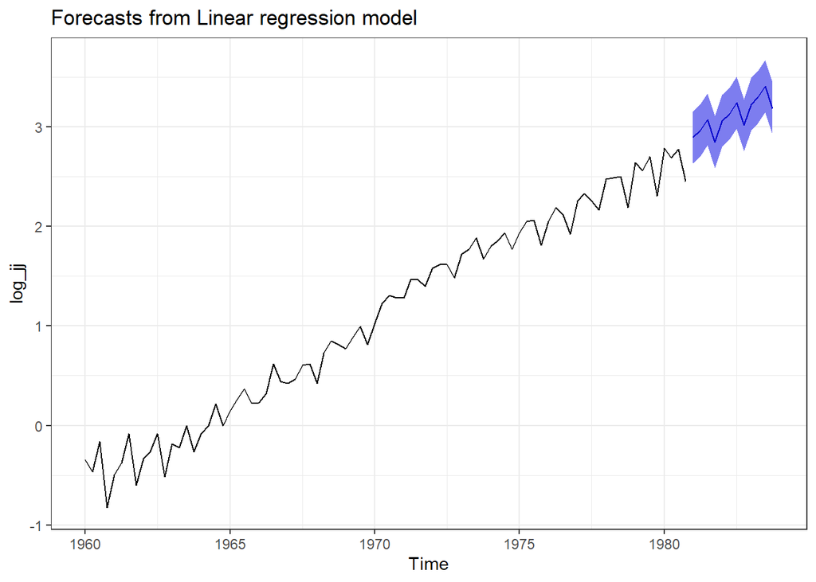

```r
forecast_3yrs = forecast(model4, h = 12, level = 95)
autoplot(forecast_3yrs)
```

```r
# to compare whether model4 is better than model2

# a) check the BIC
BIC(model4)
```

```
## [1] -89.03043
```

```r
BIC(model2)
```

```
## [1] -59.76488
```

```r
# from these values, the goodness of fit for model 4 is better since
# its BIC value is lower

# b) the accuracy values
acc_values = rbind(
  accuracy(model4),
  accuracy(model2)
)
row.names(acc_values) = c('reg w/ trend + season', 'reg w/ trend' )
acc_values
```

```
##                                                ME      RMSE       MAE  MPE MAPE
## reg w/ trend + season  0.000000000000000005580092 0.1215870 0.1007889 -Inf  Inf
## reg w/ trend          -0.000000000000000005046058 0.1566402 0.1233944  NaN  Inf
##                            MASE       ACF1
## reg w/ trend + season 0.6289143 0.31116820
## reg w/ trend          0.7699709 0.06453504
```

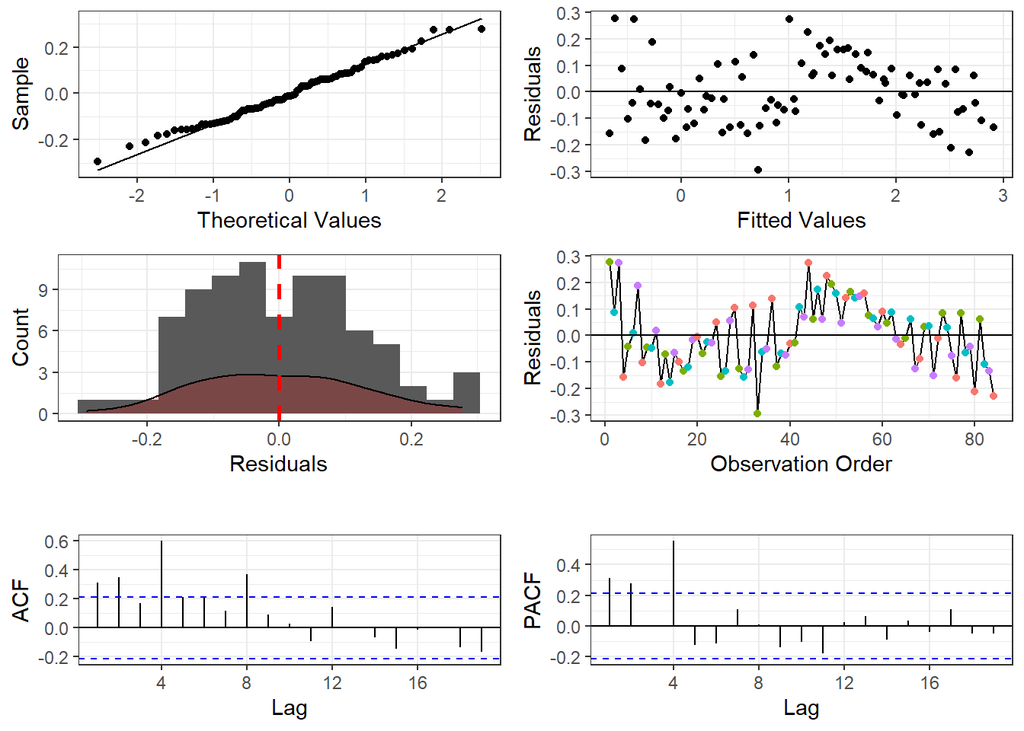

```r
# c) am I meeting the assumptions behind the regression model
# using the resplot or using the checkresiduals
resplot(res = model4$residuals, fit = model4$fitted.values, freq = 4)
```

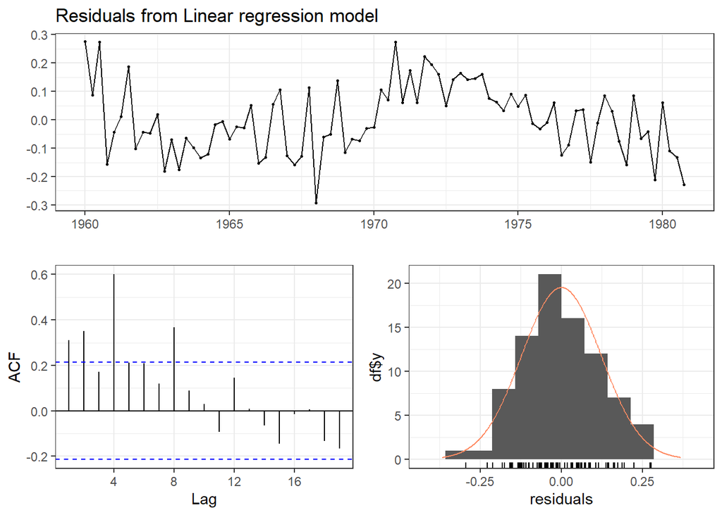

```
##
##  Breusch-Godfrey test for serial correlation of order up to 8
##
## data:  Residuals from Linear regression model
## LM test = 39.408, df = 8, p-value = 0.000004128
```

```r
checkresiduals(model4)
```

```r
# from both outputs the residuals are correlated over time so its not a good model
```

# 3 Comparison with auto.arima()

Use the log_jj data.

1. Use the `auto.arima()` function to fit an arima model to the data. What model is fit to the data?
2. Compare the residuals and the accuracy of the seasonal regression, to the auto.arima results. Which model fits better?

```r
model5 = auto.arima(log_jj)
# from the summary, we have learned about the type of ARIMA model fitted to the data
# additionally, the BIC value of -143 is lower than that of model 4
# (i.e., a better fit)
# the accuracy metrics are better than those of models 2 and 4
summary(model5)
```

```
## Series: log_jj
## ARIMA(2,0,0)(1,1,0)[4] with drift
##
## Coefficients:
##          ar1     ar2     sar1   drift
##       0.2686  0.2855  -0.2695  0.0382
## s.e.  0.1137  0.1214   0.1212  0.0042
##
## sigma^2 = 0.007793:  log likelihood = 82.47
## AIC=-154.95   AICc=-154.14   BIC=-143.04
##
## Training set error measures:
##                       ME       RMSE        MAE MPE MAPE      MASE        ACF1
## Training set 0.002030151 0.08396647 0.06504478 NaN  Inf 0.4058742 -0.03591245
```

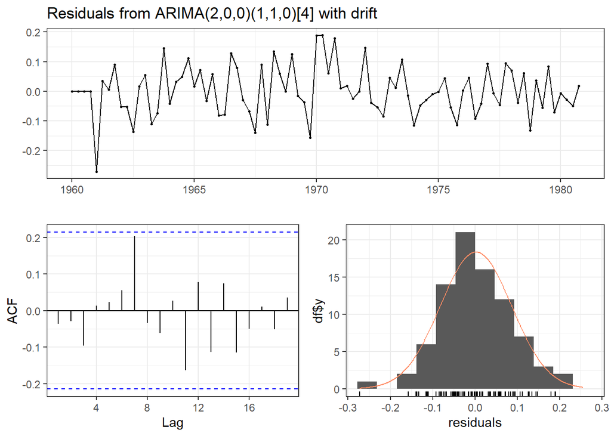

```
##
##  Ljung-Box test
##
## data:  Residuals from ARIMA(2,0,0)(1,1,0)[4] with drift
## Q* = 5.3331, df = 4, p-value = 0.2548
##
## Model df: 4.   Total lags used: 8
```

```r
# we have uncorrelated residuals over time as indicated by the plot + ljung-box test
checkresiduals(model5)
```